# Implementing Pagel’s test in diversitree:

Heath Blackmon

September 19, 2015

[Return to main website](http://coleoguy.github.io/resources.html)

Return to of comparative methods [outline](http://coleoguy.github.io/comparative/methods.html) page

# Starting points in diversitree

One issue with using diversitree is the need to pick a starting point for the parameters prior to optimization. We could just try multiple times picking number from a random uniform distribution that ranges from zero to some very large number. In fact [Dan Rabosky](http://www-personal.umich.edu/~drabosky/Home.html) even has a function in the supplemental materials from his paper with [Emma Goldberg](http://eeg.github.io/lab/home.html) [*Model Inadequacy and Mistaken Inferences of Trait-Dependent Speciation*](http://sysbio.oxfordjournals.org/content/64/2/340.short) that does just this.

It feels inelligant to pick some number that you “think” is to big. We could do this in a bit more of a quantitative method by picking a max value based on the kinds of branch length present in out tree.

```r
# first lets find the average length of a terminal branch
avg.branch <-mean(phy$edge.length[which(!phy$edge[,2] %in% phy$edge[,1])])
```

Now lets look at the way that information about the base of a branch with a length of `avg.branch` decays as the rate of evolution increases.

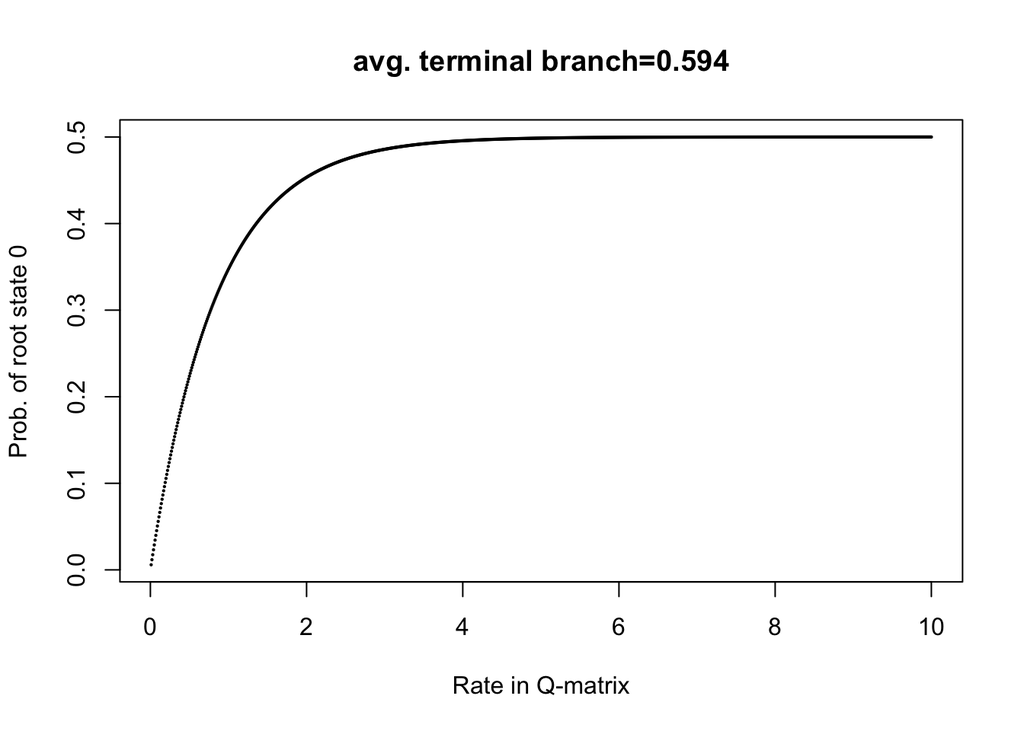

```r
x <- y <- vector()
for(i in 1:1000){
  rate <- i/100
  Q <- matrix(rate,2,2)
  diag(Q) <- -rate
  P <- ape::matexpo(Q*avg.branch)
  y[i] <- P[2,1]
  x[i] <- i/100
}
plot(x,y, pch=16,cex=.3,xlab="Rate in Q-matrix", ylab="Prob. of root state 0", main=paste("avg. terminal branch=", round(avg.branch,3), sep=""))
```

I think that looking at a plot like this for your dataset would be a good idea. It would let you pick a good value for the high end of possible starting points.

# Implementation of Pagel’s Test [1]

```r
mark <- function(phy, x, y, strict=F, pars=0.01, method="nlminb"){
  # method options are: optim, subplex, nlminb
  # nlminb is rather robust to starting parameter but
  # but is prone to convergence failure more often than
  # some of the other methods
  z <- paste(x, y, sep="")
  z[z=="00"] <- 1
  z[z=="01"] <- 2
  z[z=="10"] <- 3
  z[z=="11"] <- 4
  z <- as.numeric(z)
  names(z) <- phy$tip.label
  lk1 <- diversitree::make.mkn(phy, z, k=4, strict=F)
  lk1 <- diversitree::constrain(lk1, q14 ~ 0, q23 ~ 0, q32 ~ 0, q41 ~ 0)
  lk2 <- diversitree::constrain(lk1, q13~q24, q31~q42, q21~q43, q12~q34)
  fit1 <- diversitree::find.mle(lk1, rep(pars, 8), method=method)
  fit2 <- diversitree::find.mle(lk2, rep(pars, 4), method=method)
  m.comp <- anova(fit1, fit2)[2,5]
  return(m.comp)
}
```

```r
mark(phy, x=dd1, y=dd2)
```

```
## [1] 2.649103e-12
```

```r
mark(phy, x=ds1, y=ds2)
```

```
## [1] 0.8815785
```

```r
mark(phy, x=id1, y=id2)
```

```
## [1] 0.206683
```

```r
mark(phy, x=rb1, y=rb2)
```

```
## [1] 0.001740523
```

```r
mark(phy, x=ub1, y=ub2)
```

```
## [1] 0.01296668
```

# citations

[1] Pagel, Mark. “Detecting correlated evolution on phylogenies: a general method for the comparative analysis of discrete characters.” Proceedings of the Royal Society of London B: Biological Sciences 255, no. 1342 (1994): 37-45.

[2] Huelsenbeck, John P., Rasmus Nielsen, and Jonathan P. Bollback. “Stochastic mapping of morphological characters.” Systematic Biology 52, no. 2 (2003): 131-158.

[3] Maddison, Wayne P. “A method for testing the correlated evolution of two binary characters: are gains or losses concentrated on certain branches of a phylogenetic tree?.” Evolution (1990): 539-557.